# Bayesian Statistics

Aishameriane Schmidt

19 de março de 2017

## Exemplo 1 - Conjugada da Bernoulli/Binomial

Suponha que dois estudantes recebem uma prova com 40 questões de múltipla escolha, cada uma com 4 alternativas. É desconhecido o quanto os estudantes estudaram para a prova, porém a sua priori é que eles irão melhor do que se apenas chutassem as respostas.

Responda as seguintes questões:

**1. Quais são os parâmetros de interesse?**

*O primeiro parâmetro de interesse é $\theta_1$, que representa a probabilidade de que o primeiro aluno acerte uma questão e o segundo parâmetro é $\theta_2$, que representa a mesma probabilidade para o segundo aluno.*

**2. Qual é a verossimilhança?**

*Assumindo que os alunos respondem as questões de forma independente e que seu conhecimento sobre cada uma é o mesmo, teremos como verossimilhança uma distribuição $Binomial(n=40, \theta)$*.

3. Qual priori deve ser utilizada?

*A distribuição conjugada da Binomial é a distribuição Beta. Ela é apropriada neste caso pois o suporte de seus valores está no intervalo $[0,1]$ e é uma distribuição contínua, podendo modelar bem uma probabilidade (como é o caso do nosso $\theta$ de interesse). O gráfico da função beta pode ser visto abaixo:*

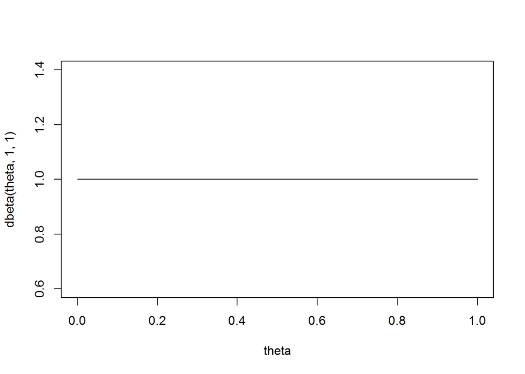

```r
# Cria um vetor com os valores para theta
theta = seq(from=0, to=1, by=0.01)

# Plota a densidade de uma beta com parâmetros alfa = beta = 1 (que é uma uniforme)
plot(theta, dbeta(theta, 1,1), type = 'l')
```

*Mas como nós temos o palpite de que os alunos irão ter desempenho melhor do que simplesmente chutando ao acaso, isso significa que temos uma crença sobre $\theta$ que é diferente do que uma distribuição uniforme representa. No caso da distribuição uniforme como priori, significa que estamos dando mesmo “peso” para todos os valores no intervalo de zero a um. Como o enunciado diz que achamos que os alunos irão ir relativamente bem em relação ao acaso, vamos tentar modelar uma distribuição beta com parâmetros $4$ e $2$. Isso nos dá uma média a priori de $\frac{4}{4+2} = \frac{2}{3} \approx 0.67$*.

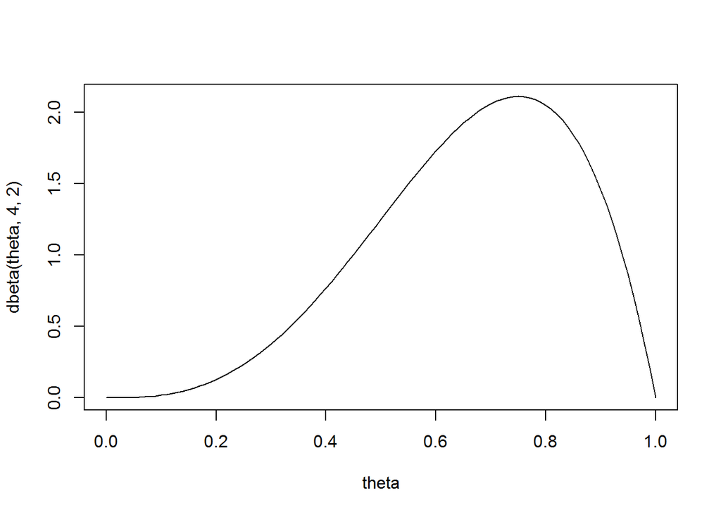

```r
theta = seq(from=0, to=1, by=0.01)

# Plota a densidade de uma beta com parâmetros alfa = 4 e beta = 2
plot(theta, dbeta(theta, 4,2), type = 'l')
```

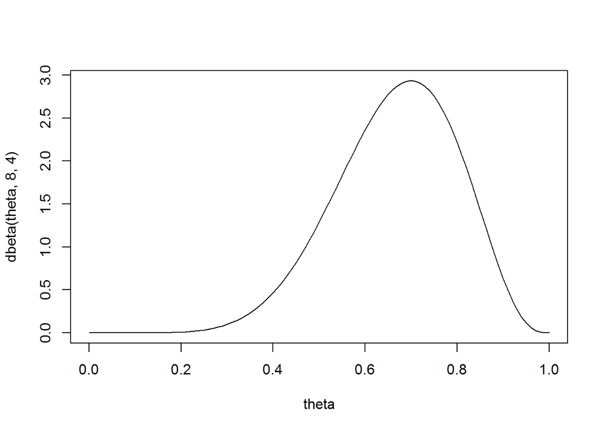

```r
theta = seq(from=0, to=1, by=0.01)

# Plota a densidade de uma beta com parâmetros alfa = 4 e beta = 2
plot(theta, dbeta(theta, 8,4), type = 'l')
```

4. Calcule as probabilidades a priori:
- $\mathbb{P}(\theta > 0.25)$

```r
# Acumulada da beta
1-pbeta(.25, 8, 4)
```

```
## [1] 0.9988117
```

- $\mathbb{P}(\theta > 0.5)$

```r
# Acumulada da beta
1-pbeta(.5, 8, 4)
```

```
## [1] 0.8867188
```

- $\mathbb{P}(\theta > 0.8)$

```r
# Acumulada da beta
1-pbeta(.8, 8, 4)
```

```
## [1] 0.1611392
```

*A posteriori será uma distribuição Beta de parâmetros $\alpha + \sum_{i=1}^40 y_i$ e $\beta = \beta + 40 - \sum_{i=1}^40 y_i$, onde $y_i$ é a indicadora de acerto na questão $i$ e portanto $\sum_{i=1}^40$ é o total de questões acertadas pelo estudante. Para o estudante 1 teremos como posteriori $f(\theta|y) \sim Beta(8+33, 4+40-33)$, isto é, $f(\theta|y) \sim Beta(41, 11)$. A média à posteriori será dada por $\frac{41}{41+11} = \frac{41}{52} =$ 0.7885. Podemos comparar com a estimativa de máxima verossimilhança, que é $\frac{33}{40} =$ 0.825. Isso significa que noss estimativa à posteriori está entre a nossa priori de $\frac{2}{3}$ e a estimativa de máxima verossimilhança. Podemos plotar o gráfico da distribuição à posteriori:*

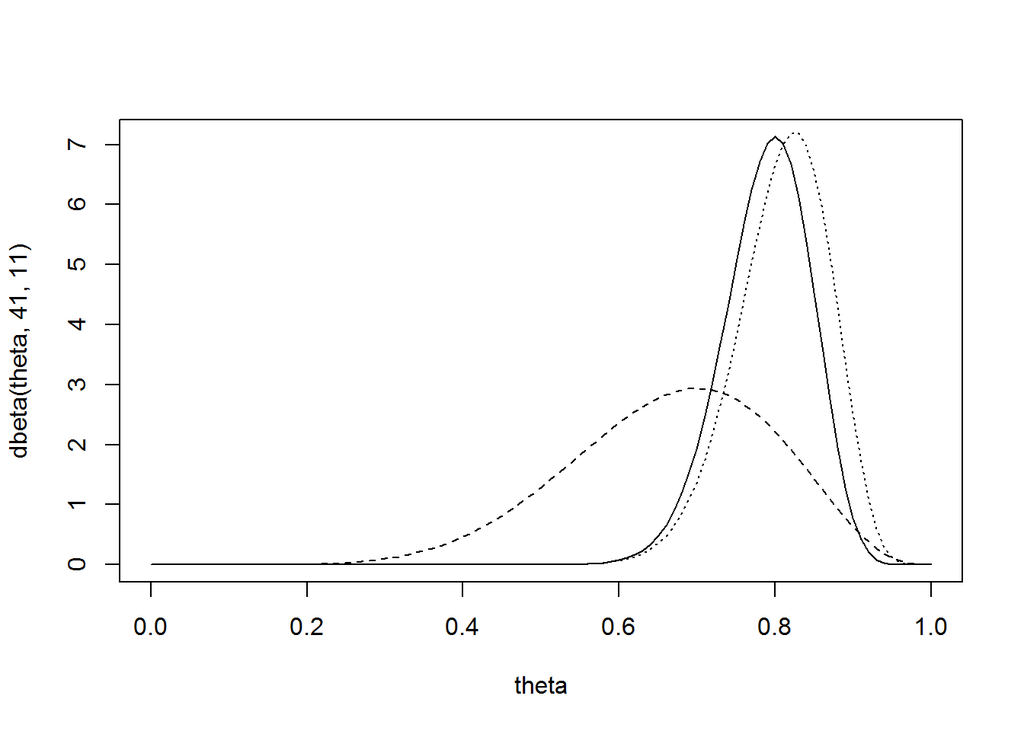

```r
theta = seq(from=0, to=1, by=0.01)

# Posteriori: beta com parâmetros alfa = 41 e beta = 11
plot(theta, dbeta(theta, 41,11), type = 'l')

# Priori: beta com parâmetros alfa = 8 e beta = 4 (pontilhada)
lines(theta, dbeta(theta, 8, 4), lty = 2)

# Verossimilhança multiplicada por um fator para deixar ela na mesma escala
lines(theta, 44*dbinom(33, size=40, p=theta), lty=3)
```

*A posteriori está entre a verossimilhança e a priori, porém está mais próxima da verossimilhança pois o peso dela é de $n=40$ enquanto que o peso da priori é de $\alpha + \beta = 12$.*

*Podemos calcular as probabilidades a posteriori:*

- $\mathbb{P}(\theta_1 > 0.25)$

```r
# Acumulada da beta
1-pbeta(.25, 41,11)
```

```
## [1] 1
```

- $\mathbb{P}(\theta_1 > 0.5)$

```r
# Acumulada da beta
1-pbeta(.5, 41, 11)
```

```
## [1] 0.9999926
```

- $\mathbb{P}(\theta_1 > 0.8)$

```r
# Acumulada da beta
1-pbeta(.8, 41,11)
```

```
## [1] 0.4444044
```

*Observe que agora a probabilidade de $\theta_1 > 0.8$ passou a ser maior que $0.44$.*

*Um intervalo de 95% credibilidade para $\theta_1$ é (0.6688,0.8871), que é consistente com o observado no gráfico da posteriori*.

6. Suponha que o segundo estudante acertou 24 (0.6) questões. Qual é a distribuição à posteriori para $\theta_1$? Calcule $\mathbb{P}(\theta_2 > 0.25)$, $\mathbb{P}(\theta_2 > 0.5)$ e $\mathbb{P}(\theta_2 > 0.8)$. Dê um intervalo de 95% de credibilidade a posteriori para $\theta_2$.

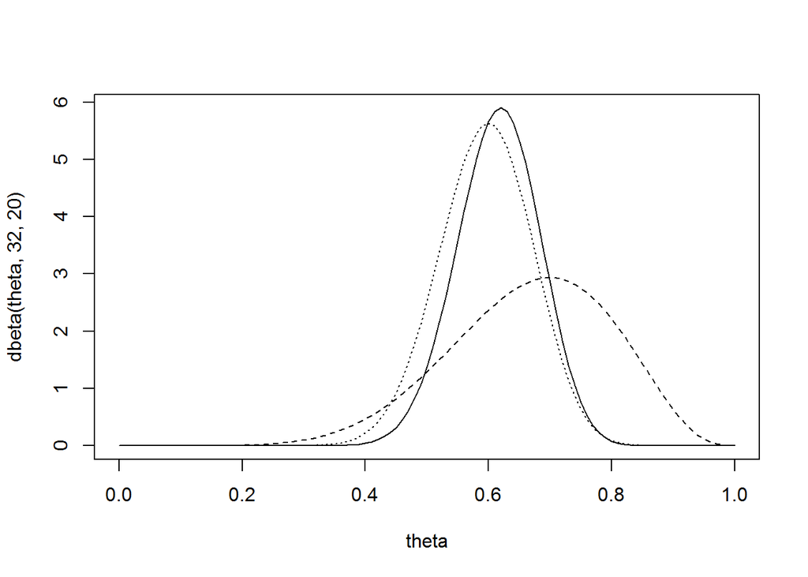

```r
theta = seq(from=0, to=1, by=0.01)

# Posteriori: beta com parâmetros alfa = 32 e beta = 20
plot(theta, dbeta(theta, 32,20), type = 'l')

# Priori: beta com parâmetros alfa = 8 e beta = 4 (pontilhada)
lines(theta, dbeta(theta, 8, 4), lty = 2)

# Verossimilhança multiplicada por um fator para deixar ela na mesma escala
lines(theta, 44*dbinom(24, size=40, p=theta), lty=3)
```

*Podemos calcular as probabilidades a posteriori:*

- $\mathbb{P}(\theta_1 > 0.25)$

```r
# Acumulada da beta
1-pbeta(.25, 32,20)
```

```
## [1] 1
```

- $\mathbb{P}(\theta_1 > 0.5)$

```r
# Acumulada da beta
1-pbeta(.5, 32, 20)
```

```
## [1] 0.9540427
```

- $\mathbb{P}(\theta_1 > 0.8)$

```r
# Acumulada da beta
1-pbeta(.8, 32,20)
```

```
## [1] 0.00124819
```

*Um intervalo de 95% credibilidade para $\theta_2$ é (0.4808,0.7416), que é consistente com o observado no gráfico da posteriori*.

7. Qual é a probabilidade a posteriori que $\theta_1 > \theta_2$, isto é, o primeiro estudante tem maior chance de acertar uma questão que o segundo aluno?

*Vamos fazer 1000 amostras de cada posteriori para responder a questão via simulação.*

```r
theta1=rbeta(1000,41,11)
theta2=rbeta(1000,32,20)
mean(theta1>theta2)
```

```
## [1] 0.982
```